# Book Club Details

## Book Club

Depending on the book you signed up for (**see sign-ups at the bottom of this document**), here are the instructions:

1. If you signed up for **Factfulness**

Your topic is one of these:

- Conduct the “test yourself” survey with at least 20 Brown School students who are not in ALM this semester. Examine the data and present the results, comparing them with the results discussed in the book.
- Discuss dramatic instincts and how they shape what we know.
- What did Hans Rosling get wrong and why?
- How can you use the ideas from Factfulness in your everyday life and/or your career?

Work with your book club group to develop an activity related to your topic. This can take *any format* as long as the format encourages some sort of participation by the rest of the class. You should plan something that takes 20-30 minutes total. In the past, groups have:

- Developed a set of questions to lead the class in a discussion (be sure to think about how to proceed if the class is very quiet!)
- Developed a Jeopardy, Who wants to be a millionaire, or other game show type game and had the class compete as individuals or teams to answer questions
- Divided the class into groups and had each group come up with the answer to a question and present their answer in some way
- Demonstrated new R command(s) or package(s) related to the book and walked the class through how to use them
- Demonstrated some statistical concept or formula related to the book and walked the class through how to use it/think about it
- Developed a mystery related to the topic with clues the class had to solve
- Developed a matching game where ideas or names are written on the board and individual students are each given a notecard with a fact to tape next to its matching idea or name
- Tested one of the ideas in the book with a brief in-class study
- Wrote a short play or scenario and acted it out
2. If you signed up for **Signal and the Noise**, **Rigor Mortis**, or **Drunkard’s Walk** you will do the same thing as above, but since nobody else in class read your book, you have a little extra time (plan on 30-40 mins) that should be used to summarize the book before move into the discussion or activity. When developing the activity/discussion, keep in mind that nobody else read the book.

OTHER STUFF for everyone regardless of book:

- You will be reviewing your teammates and their contributions to your book club group, so be aware that this is part of the score. Your participation in book club also includes participating in whatever activities the other groups come up with, so *reading the book* is important!
- If you need me to make copies or other materials for your activity, please email me at least one day ahead of time.

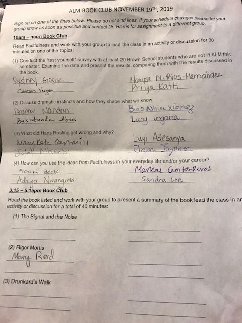

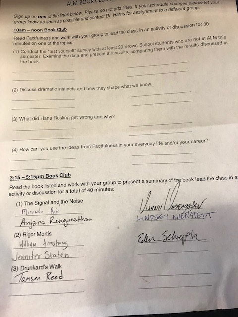